# Zadanie6

Rymon Lipinska

8 czerwca 2018

# *The 100* - amerykański serial

Serial jest adaptacją książki *Misja 100* autorstwa Kass Morgan, która napisała także scenariusz serialu wspólnie z Jasonem Rothenbergiem

### Produkcja

- Pilot serialu był kręcony w Vancouver (Kanada)
- 9 maja 2013 roku The CW zamówiła serial na sezon telewizyjny 2013/14
- 11 stycznia 2015 roku ogłoszono, że stacja The CW zamówiła 3 sezon serialu
- 11 marca 2016 roku ogłoszono, że stacja The CW zamówiła kolejny, czwarty sezon serialu.
- Informacje o zamówieniu 5. sezonu The 100 ogłosił Mark Pedowitz, prezes stacji The CW. Nie wyjawiono jednak, ile będzie odcinków. Premiera ma się odbyć 24 kwietnia 2018 roku.
- 8 maja 2018 roku, stacja The CW przedłużyła serial o szósty sezon

### Lista pięciu najlepiej ocenianych aktorów grających w serialu (według użytkowników [filmweb](http://www.filmweb.pl/))

1. **Alycia Debnam-Carey** (jako Lexa)
2. **Bob Morley** (jako Bellamy Blake)
3. **Ricky Whittle** (jako Lincoln)
4. **Marie Avgeropoulos** (jako Octavia Blake)
5. **Richard Harmon** (jako John Murphy)

### Odcinki

| SEZON | ODCINKI | ORYGINALNA EMISJA (premiera-finał sezonu) |
| --- | --- | --- |
| **1** | 13 | 19.03.2014-11.06.2014 |
| **2** | 16 | 22.10.2014-11.03.2015 |
| **3** | 16 | 21.01.2016-19.05.2016 |
| **4** | 13 | 01.02.2017-24.05.2017 |
| **5** | 13 | 24.04.2018- |

## Cytat mojego *ulubionego* bohatera

> Każdy ma w sobie potwora i jest za niego odpowiedzialny - Lincoln

## A tutaj poza temacikiem

```r
mpg
```

| manufacturer | model | displ | year | cyl | trans | drv | cty | hwy | fl | class |
| --- | --- | --- | --- | --- | --- | --- | --- | --- | --- | --- |
| audi | a4 | 1.8 | 1999 | 4 | auto(l5) | f | 18 | 29 | p | compact |
| audi | a4 | 1.8 | 1999 | 4 | manual(m5) | f | 21 | 29 | p | compact |
| audi | a4 | 2.0 | 2008 | 4 | manual(m6) | f | 20 | 31 | p | compact |
| audi | a4 | 2.0 | 2008 | 4 | auto(av) | f | 21 | 30 | p | compact |
| audi | a4 | 2.8 | 1999 | 6 | auto(l5) | f | 16 | 26 | p | compact |
| audi | a4 | 2.8 | 1999 | 6 | manual(m5) | f | 18 | 26 | p | compact |
| audi | a4 | 3.1 | 2008 | 6 | auto(av) | f | 18 | 27 | p | compact |
| audi | a4 quattro | 1.8 | 1999 | 4 | manual(m5) | 4 | 18 | 26 | p | compact |
| audi | a4 quattro | 1.8 | 1999 | 4 | auto(l5) | 4 | 16 | 25 | p | compact |
| audi | a4 quattro | 2.0 | 2008 | 4 | manual(m6) | 4 | 20 | 28 | p | compact |

[output cut: 224 more lines]

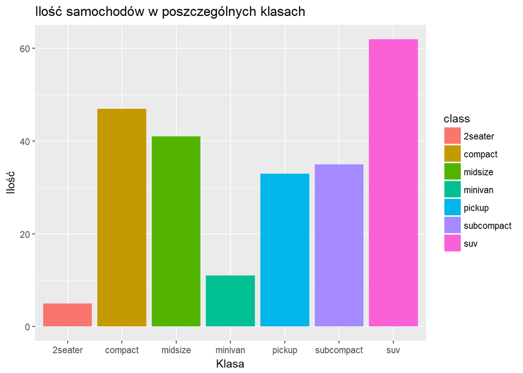

> `ggplot(data = mpg) + geom_bar(mapping = aes(x = class, fill = class)) + labs(title = "Ilość samochodów w poszczególnych klasach", x = "Klasa", y = "Ilość")`